## Database overview

The Forest C database (ForC-db) is an open access global C database led by Dr. Kristina Anderson-Teixeira (Smithsonian). ForC is updated and maintained in [this Github repository](https://github.com/forc-db/ForC) and is [visualized here](https://forc.shinyapps.io/global_data_visualization/). The database contains previously published data on ground-based measurements of ecosystem-level C stocks and annual fluxes in forests globally, along with site information, disturbance history, and information on methodology. It currently contains >17,500 records from >2,700 plots and >2,000 sites, making it the largest and most comprehensive database of its type. These data were obtained from multiple previous compilations and individual published studies, as detailed in [Anderson-Teixeira et al. (2016)](http://onlinelibrary.wiley.com/doi/10.1111/gcb.13226/abstract) and [Anderson-Teixeira et al. (2018)](https://esajournals.onlinelibrary.wiley.com/doi/10.1002/ecy.2229).

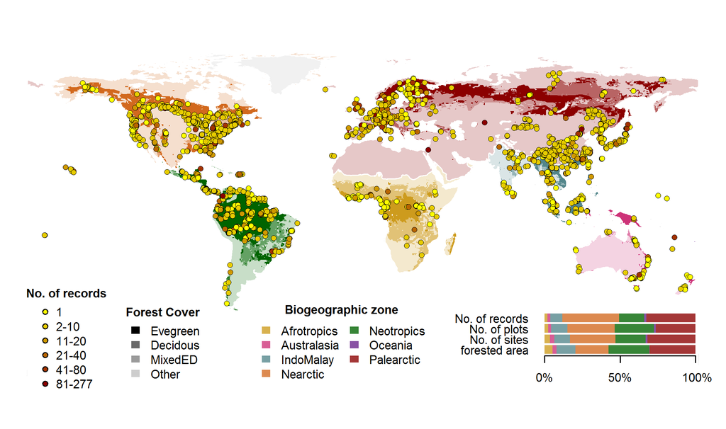

**Geographical distributions of sites included in ForC-db.** Symbols are colored according to the number of records from each site. Underlying map shows coverage of evergreen, deciduous, and mixed forests (from SYNMAP; Jung et al. 2006) and biogeographic zones (Olson et al. 2001). Distribution of sites, plots, and records among biogeographic zones is shown in the inset.

Previous versions of ForC have been published in the peer-reviewed literature: [Anderson-Teixeira et al. (2016)](http://onlinelibrary.wiley.com/doi/10.1111/gcb.13226/abstract) and [Anderson-Teixeira et al. (2018)](https://esajournals.onlinelibrary.wiley.com/doi/10.1002/ecy.2229). ForC is continuously developing, and the version on Github is always the current master. Interested users may contact database PI Dr. Kristina Anderson-Teixeira for an update on status and to discuss collaboration.

## Data Use

ForC-db is an open access database, and we encourage use of the data for scientific research and educational purposes. All users are responsible to adhere to the data use policy: [`DATA USE.md`](https://github.com/forc-db/ForC/blob/master/DATA%20USE.md).

## Contributing to the database

We anticipate that ForC-db will be of great value for various initiatives seeking to understand and manage the role of tropical forests in the global C cycle, and we encourage authors to contribute data. Please see [`CONTRIBUTING.md`](https://github.com/forc-db/ForC/blob/master/CONTRIBUTING.md).

## Database citations

Any publications using ForC data should cite the following publications:

- Anderson-Teixeira, K.J. *et al.* 2016. Carbon dynamics of mature and regrowth tropical forests derived from a pantropical database (TropForC-db). Global Change Biology. DOI: 10.1111/gcb.13226
- Anderson-Teixeira, K. J., M. M. H. Wang, J. C. McGarvey, V. Herrmann, A. J. Tepley, B. P. Bond-Lamberty, and D. S. LeBauer. in press. ForC: a global database of forest carbon stocks and fluxes. Ecology. DOI: 10.1002/ecy.2229.

In addition, if data are obtained from [the Github repository](https://github.com/forc-db/ForC) (as opposed to a static version associated with one of the above publications), this should be referenced as well (DOI representing all versions: [10.5281/zenodo.1135088](https://doi.org/10.5281/zenodo.1187192)). Publications should cite a specific version of ForC, ideally with a DOI associated with that version. Authors may work with ForC managers to generate a release and associated DOI that matches the database version used in their publication.

## Funding acknowledgements

- DOE Terrestrial Ecosystem Science grant DE-SC0008085/ DE-SC0010039 to Kristina Anderson-Teixeira, Evan DeLucia, and Benjamin Duval
- Smithsonian Women’s Committee grant to Kristina Anderson-Teixeira
- Smithsonian Scholarly Studies grant to Kristina Anderson-Teixeira and Helene Muller-Landau